# Results from lab pilot

```r
library(tidyverse)
library(ggpubr)
```

```r
lab_data <- here::here(
  "analysis",
  "lab_pilot",
  "data",
  "processed",
  "combined_lab_pilot_data.csv"
) %>%
  read_csv()

lab_data <- lab_data %>%
  tidyr::separate(
    stimulus_song,
    into = c("folder", "file"),
    sep = "/"
  )
```

# Overview

The pilot presented a range of musical clips (1 sec in duration) that were taken from songs that had been tagged as happy, sad, angry, or relaxed on last.fm. Participants rated the emotion of the musical clip, it’s expressed valence and expressed arousal.

As shown below, the data have been structure so that each trial is in one row. Target refelcts what to song was tagged as and emotion reflects the emotion the participant labelled the clip as.

| subject | trial_index | folder | file | target | emotion | valence | arousal | correct |
| --- | --- | --- | --- | --- | --- | --- | --- | --- |
| r5l2vw7lqxdnfg7 | 22 | audio | 2_Incomplete.mp3 | angry | angry | 20 | 78 | TRUE |
| vzpuh9a0oxg5jbc | 4 | audio | 2_Sweet_Song.mp3 | relaxed | relaxed | 40 | 14 | TRUE |
| mr02t2o5o3n8nu8 | 17 | audio | 4_Make_Light.mp3 | happy | relaxed | 63 | 32 | FALSE |
| esfsup646pd4dc3 | 4 | audio | 19_I_hate_Everything_About_You.mp3 | angry | sad | 43 | 62 | FALSE |
| wto40f559ergwfw | 24 | audio | 8_Fire_And_Rain__(LP_Version).mp3 | sad | sad | 31 | 33 | TRUE |
| vzpuh9a0oxg5jbc | 17 | audio | 4_Mbube.mp3 | relaxed | happy | 66 | 41 | FALSE |
| s20encxw28459xp | 34 | audio | 4_Make_Light.mp3 | happy | happy | 50 | 78 | TRUE |
| esfsup646pd4dc3 | 15 | audio | 2_Inside.mp3 | sad | sad | 46 | 55 | TRUE |
| qd7yfgtyypvrqy3 | 21 | mp3 | 7_Here_Today.mp3 | relaxed | sad | 37 | 0 | FALSE |
| wto40f559ergwfw | 43 | audio | 2_Sweet_Song.mp3 | relaxed | sad | 17 | 15 | FALSE |

# Calculating accuracy

## Participant ranges

```r
p_id <- lab_data %>%
  select(subject) %>%
  distinct() %>%
  as.list() %>%
  .$subject

lab_accuracy <- data.frame(stringsAsFactors = FALSE)

for (i in 1:length(p_id)) {
  sub_tmp <- p_id[i]
  data_tmp <- lab_data %>%
    filter(subject == sub_tmp)
  obs_tmp <- nrow(data_tmp)
  correct_tmp <- data_tmp %>%
    filter(correct == TRUE) %>%
    nrow()
  acc_tmp <- ((correct_tmp / obs_tmp) * 100)
  row_tmp <- cbind(sub_tmp, obs_tmp, correct_tmp, acc_tmp)
  lab_accuracy <- rbind(lab_accuracy, row_tmp)
}

fac_to_num <- function(.x) {
  as.numeric(as.character(.x))
}

lab_accuracy <- lab_accuracy %>%
  mutate_at(.vars = vars("obs_tmp", "correct_tmp", "acc_tmp"), fac_to_num)
```

It would be helpful to see if there is variance in participant responses.

The results indicate that the mean accuracy was 62.22 with a standard deviation of 14.34.

## Accuracy by emotion

I would like to see the accuracy for each emotion. It can be seen that relaxation was the most difficult to accurately categorise

```r
by_file <- lab_data %>%
  group_by(target) %>%
  summarise(prop_correct = sum(correct) / n()) %>%
  arrange(target)

by_file %>%
  knitr::kable(
    format = "html",
  ) %>%
  kableExtra::kable_styling(
    bootstrap_options = "hover"
  )
```

| target | prop_correct |
| --- | --- |
| angry | 0.7142857 |
| happy | 0.6320755 |
| relaxed | 0.4821429 |
| sad | 0.6486486 |

```r
table(lab_data$target,
      lab_data$emotion) %>%
  knitr::kable(
    format = "html"
  ) %>%
    kableExtra::kable_styling(
    bootstrap_options = "hover"
  )
```

|  | angry | happy | none of these | relaxed | sad |
| --- | --- | --- | --- | --- | --- |
| angry | 30 | 3 | 5 | 0 | 4 |
| happy | 3 | 67 | 20 | 11 | 5 |
| relaxed | 0 | 10 | 11 | 27 | 8 |
| sad | 1 | 3 | 8 | 27 | 72 |

## Accuracy by song

```r
by_song <- lab_data %>%
  group_by(file) %>%
  mutate(prop_correct = sum(correct) / n()) %>%
  distinct(
    file,
    .keep_all = TRUE
  ) %>%
  select(
    target,
    emotion,
    file,
    prop_correct
  ) %>%
  arrange(target)

by_song %>%
  knitr::kable(
    format = "html",
  ) %>%
  kableExtra::kable_styling(
    bootstrap_options = "hover"
  ) %>%
  kableExtra::scroll_box(
    height = "250px"
  )
```

| target | emotion | file | prop_correct |
| --- | --- | --- | --- |
| angry | none of these | 9_Pain_(Live_Version).mp3 | 0.7142857 |
| angry | angry | 2_Incomplete.mp3 | 0.7142857 |
| angry | sad | 19_I_hate_Everything_About_You.mp3 | 0.7142857 |
| angry | happy | 2_Blood_On_The_Ground.mp3 | 0.7142857 |
| angry | happy | 13_Motown_Junk.mp3 | 0.4285714 |
| angry | angry | 15_Bunkertor_7_(German_Texture).mp3 | 1.0000000 |
| happy | happy | 9_If_The_Creeks_Don’t_Rise.mp3 | 0.7142857 |
| happy | none of these | 8_Restless.mp3 | 0.5714286 |
| happy | happy | 1_Be_Happy.mp3 | 0.4285714 |
| happy | none of these | 5_Valerie.mp3 | 0.7142857 |
| happy | happy | 4_Make_Light.mp3 | 0.7142857 |
| happy | none of these | 26_Make_Light.mp3 | 0.4285714 |
| happy | happy | 24_Restless.mp3 | 0.8571429 |
| happy | none of these | 11_Be_Happy.mp3 | 0.5714286 |
| happy | happy | 14_Get_Lucky.mp3 | 0.7142857 |
| happy | none of these | 28_Valerie.mp3 | 0.7142857 |
| happy | happy | 21_Skank_Down.mp3 | 0.5714286 |
| happy | happy | 12_Skank_Down.mp3 | 0.8571429 |
| happy | sad | 13_If_The_Creeks_Don’t_Rise.mp3 | 0.4285714 |
| happy | none of these | 16_Restless.mp3 | 0.7142857 |
| happy | none of these | 5_Get_Lucky.mp3 | 0.4285714 |
| relaxed | relaxed | 4_Destiny.mp3 | 0.4285714 |
| relaxed | relaxed | 1_The_Sweetest.mp3 | 0.5714286 |
| relaxed | relaxed | 3_Walk_on_the_wild_side.mp3 | 1.0000000 |
| relaxed | none of these | 7_Digital.mp3 | 0.0000000 |
| relaxed | happy | 4_Mbube.mp3 | 0.1428571 |
| relaxed | relaxed | 2_On_A_Slow_Boat_To_China.mp3 | 0.5714286 |
| relaxed | relaxed | 4_Come_On_Baby.mp3 | 0.8571429 |
| relaxed | sad | 2_Sweet_Song.mp3 | 0.4285714 |
| sad | sad | 2_Love’s_Requiem.mp3 | 0.8571429 |
| sad | sad | 7_Here_Today.mp3 | 0.4285714 |
| sad | sad | 1_Skinny_Love.mp3 | 1.0000000 |
| sad | sad | 26_It_Only_Hurts_When_I’m_Breathing.mp3 | 1.0000000 |
| sad | sad | 2_Inside.mp3 | 0.8571429 |
| sad | none of these | 12_Fire_And_Rain_(LP_Version).mp3 | 0.2857143 |
| sad | relaxed | 15_Here_Today.mp3 | 0.4285714 |
| sad | sad | 3_It_Only_Hurts_When_I’m_Breathing.mp3 | 0.4285714 |
| sad | none of these | 8_Fire_And_Rain__(LP_Version).mp3 | 0.4285714 |
| sad | relaxed | 2_Boser_Wolf.mp3 | 0.5714286 |
| sad | sad | 25_Old_Blacktop_[Album_Version].mp3 | 0.7142857 |
| sad | sad | 12_Skinny_Love.mp3 | 0.8571429 |
| sad | none of these | 23_Inside.mp3 | 0.5714286 |
| sad | sad | 5_Love’s_Requiem.mp3 | 1.0000000 |
| sad | sad | 3_Old_Blacktop_[Album_Version].mp3 | 0.7142857 |
| sad | relaxed | 13_Boser_Wolf.mp3 | 0.1428571 |

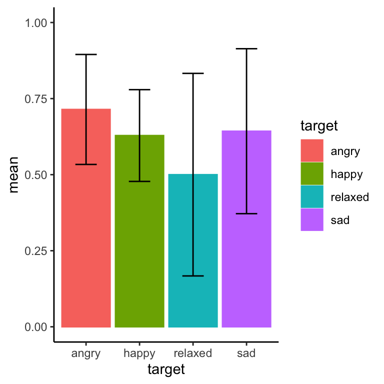

```r
by_song %>%
  group_by(target) %>%
  summarise(mean = mean(prop_correct),
            sd = sd(prop_correct)) %>%
  ggplot2::ggplot(
    aes(x = target,
        y = mean,
        color = target,
        fill = target
    )
  ) +
  ggplot2::geom_bar(
    stat = "identity"
  ) +
  geom_errorbar(
    aes(ymin = mean - sd,
        ymax = mean + sd),
    width = .4,
    color = "black"
  ) +
  ggplot2::ylim(0, 1) +
  ggplot2::theme_classic()
```

I am largely interested in happy and sad songs that appear viable in terms of variability. For this is set accuracy as above 50%

```r
by_song %>%
  filter(
    prop_correct > .5
    ) %>%
  arrange(target) %>%
  knitr::kable(
    format = "html"
  ) %>%
  kableExtra::kable_styling(
    bootstrap_options = "hover"
  ) %>%
  kableExtra::scroll_box(
    height = "250px"
  )
```

| target | emotion | file | prop_correct |
| --- | --- | --- | --- |
| angry | none of these | 9_Pain_(Live_Version).mp3 | 0.7142857 |
| angry | angry | 2_Incomplete.mp3 | 0.7142857 |
| angry | sad | 19_I_hate_Everything_About_You.mp3 | 0.7142857 |
| angry | happy | 2_Blood_On_The_Ground.mp3 | 0.7142857 |
| angry | angry | 15_Bunkertor_7_(German_Texture).mp3 | 1.0000000 |
| happy | happy | 9_If_The_Creeks_Don’t_Rise.mp3 | 0.7142857 |
| happy | none of these | 8_Restless.mp3 | 0.5714286 |
| happy | none of these | 5_Valerie.mp3 | 0.7142857 |
| happy | happy | 4_Make_Light.mp3 | 0.7142857 |
| happy | happy | 24_Restless.mp3 | 0.8571429 |
| happy | none of these | 11_Be_Happy.mp3 | 0.5714286 |
| happy | happy | 14_Get_Lucky.mp3 | 0.7142857 |
| happy | none of these | 28_Valerie.mp3 | 0.7142857 |
| happy | happy | 21_Skank_Down.mp3 | 0.5714286 |
| happy | happy | 12_Skank_Down.mp3 | 0.8571429 |
| happy | none of these | 16_Restless.mp3 | 0.7142857 |
| relaxed | relaxed | 1_The_Sweetest.mp3 | 0.5714286 |
| relaxed | relaxed | 3_Walk_on_the_wild_side.mp3 | 1.0000000 |
| relaxed | relaxed | 2_On_A_Slow_Boat_To_China.mp3 | 0.5714286 |
| relaxed | relaxed | 4_Come_On_Baby.mp3 | 0.8571429 |
| sad | sad | 2_Love’s_Requiem.mp3 | 0.8571429 |
| sad | sad | 1_Skinny_Love.mp3 | 1.0000000 |
| sad | sad | 26_It_Only_Hurts_When_I’m_Breathing.mp3 | 1.0000000 |
| sad | sad | 2_Inside.mp3 | 0.8571429 |
| sad | relaxed | 2_Boser_Wolf.mp3 | 0.5714286 |
| sad | sad | 25_Old_Blacktop_[Album_Version].mp3 | 0.7142857 |
| sad | sad | 12_Skinny_Love.mp3 | 0.8571429 |
| sad | none of these | 23_Inside.mp3 | 0.5714286 |
| sad | sad | 5_Love’s_Requiem.mp3 | 1.0000000 |
| sad | sad | 3_Old_Blacktop_[Album_Version].mp3 | 0.7142857 |

As there are time constraints I also want to see the songs with very poor accuracy

```r
by_song %>%
  filter(
    prop_correct < .45
    ) %>%
  arrange(target) %>%
  knitr::kable(
    format = "html"
  ) %>%
  kableExtra::kable_styling(
    bootstrap_options = "hover"
  ) %>%
  kableExtra::scroll_box(
    height = "250px"
  )
```

| target | emotion | file | prop_correct |
| --- | --- | --- | --- |
| angry | happy | 13_Motown_Junk.mp3 | 0.4285714 |
| happy | happy | 1_Be_Happy.mp3 | 0.4285714 |
| happy | none of these | 26_Make_Light.mp3 | 0.4285714 |
| happy | sad | 13_If_The_Creeks_Don’t_Rise.mp3 | 0.4285714 |
| happy | none of these | 5_Get_Lucky.mp3 | 0.4285714 |
| relaxed | relaxed | 4_Destiny.mp3 | 0.4285714 |
| relaxed | none of these | 7_Digital.mp3 | 0.0000000 |
| relaxed | happy | 4_Mbube.mp3 | 0.1428571 |
| relaxed | sad | 2_Sweet_Song.mp3 | 0.4285714 |
| sad | sad | 7_Here_Today.mp3 | 0.4285714 |
| sad | none of these | 12_Fire_And_Rain_(LP_Version).mp3 | 0.2857143 |
| sad | relaxed | 15_Here_Today.mp3 | 0.4285714 |
| sad | sad | 3_It_Only_Hurts_When_I’m_Breathing.mp3 | 0.4285714 |
| sad | none of these | 8_Fire_And_Rain__(LP_Version).mp3 | 0.4285714 |
| sad | relaxed | 13_Boser_Wolf.mp3 | 0.1428571 |

### Confusion matrix by song

#### Happy songs

```r
happy <- lab_data %>%
    filter(target == "happy")

table(
    happy$file,
      happy$emotion
    ) %>%
  knitr::kable(
    format = "html"
  ) %>%
    kableExtra::kable_styling(
    bootstrap_options = "hover"
  )
```

|  | angry | happy | none of these | relaxed | sad |
| --- | --- | --- | --- | --- | --- |
| 1_Be_Happy.mp3 | 0 | 3 | 1 | 1 | 2 |
| 11_Be_Happy.mp3 | 0 | 4 | 1 | 1 | 1 |
| 12_Skank_Down.mp3 | 0 | 6 | 1 | 0 | 0 |
| 13_If_The_Creeks_Don’t_Rise.mp3 | 0 | 3 | 1 | 2 | 1 |
| 14_Get_Lucky.mp3 | 0 | 5 | 1 | 1 | 0 |
| 16_Restless.mp3 | 1 | 5 | 1 | 0 | 0 |
| 21_Skank_Down.mp3 | 1 | 4 | 2 | 0 | 0 |
| 24_Restless.mp3 | 0 | 6 | 0 | 1 | 0 |
| 26_Make_Light.mp3 | 0 | 3 | 3 | 1 | 0 |
| 28_Valerie.mp3 | 1 | 5 | 1 | 0 | 0 |
| 4_Make_Light.mp3 | 0 | 5 | 0 | 2 | 0 |
| 4_Mbube.mp3 | 0 | 1 | 0 | 0 | 0 |
| 5_Get_Lucky.mp3 | 0 | 3 | 2 | 2 | 0 |
| 5_Valerie.mp3 | 0 | 5 | 2 | 0 | 0 |
| 8_Restless.mp3 | 0 | 4 | 3 | 0 | 0 |
| 9_If_The_Creeks_Don’t_Rise.mp3 | 0 | 5 | 1 | 0 | 1 |

```r
sad <- lab_data %>%
    filter(target == "sad")

table(
    sad$file,
      sad$emotion
    ) %>%
  knitr::kable(
    format = "html"
  ) %>%
    kableExtra::kable_styling(
    bootstrap_options = "hover"
  )
```

|  | angry | happy | none of these | relaxed | sad |
| --- | --- | --- | --- | --- | --- |
| 1_Skinny_Love.mp3 | 0 | 0 | 0 | 0 | 7 |
| 12_Fire_And_Rain_(LP_Version).mp3 | 0 | 0 | 1 | 4 | 2 |
| 12_Skinny_Love.mp3 | 0 | 0 | 0 | 1 | 6 |
| 13_Boser_Wolf.mp3 | 1 | 0 | 0 | 5 | 1 |
| 15_Here_Today.mp3 | 0 | 1 | 0 | 3 | 3 |
| 2_Boser_Wolf.mp3 | 0 | 0 | 1 | 2 | 4 |
| 2_Inside.mp3 | 0 | 0 | 0 | 1 | 6 |
| 2_Love’s_Requiem.mp3 | 0 | 0 | 0 | 1 | 6 |
| 23_Inside.mp3 | 0 | 1 | 1 | 1 | 4 |
| 25_Old_Blacktop_[Album_Version].mp3 | 0 | 0 | 1 | 1 | 5 |
| 26_It_Only_Hurts_When_I’m_Breathing.mp3 | 0 | 0 | 0 | 0 | 7 |
| 3_It_Only_Hurts_When_I’m_Breathing.mp3 | 0 | 1 | 2 | 1 | 3 |
| 3_Old_Blacktop_[Album_Version].mp3 | 0 | 0 | 0 | 2 | 5 |
| 5_Love’s_Requiem.mp3 | 0 | 0 | 0 | 0 | 7 |
| 7_Here_Today.mp3 | 0 | 0 | 1 | 2 | 3 |
| 8_Fire_And_Rain__(LP_Version).mp3 | 0 | 0 | 1 | 3 | 3 |

#### relaxed songs

```r
relaxed <- lab_data %>%
    filter(target == "relaxed")

table(
    relaxed$file,
      relaxed$emotion
    ) %>%
  knitr::kable(
    format = "html"
  ) %>%
    kableExtra::kable_styling(
    bootstrap_options = "hover"
  )
```

|  | happy | none of these | relaxed | sad |
| --- | --- | --- | --- | --- |
| 1_The_Sweetest.mp3 | 0 | 3 | 4 | 0 |
| 2_On_A_Slow_Boat_To_China.mp3 | 2 | 1 | 4 | 0 |
| 2_Sweet_Song.mp3 | 0 | 0 | 3 | 4 |
| 3_Walk_on_the_wild_side.mp3 | 0 | 0 | 7 | 0 |
| 4_Come_On_Baby.mp3 | 0 | 0 | 6 | 1 |
| 4_Destiny.mp3 | 2 | 2 | 3 | 0 |
| 4_Mbube.mp3 | 5 | 1 | 0 | 0 |
| 7_Digital.mp3 | 1 | 4 | 0 | 2 |
| 7_Here_Today.mp3 | 0 | 0 | 0 | 1 |

#### angry songs

```r
angry <- lab_data %>%
    filter(target == "angry")

table(
    angry$file,
      angry$emotion
    ) %>%
  knitr::kable(
    format = "html"
  ) %>%
    kableExtra::kable_styling(
    bootstrap_options = "hover"
  )
```

|  | angry | happy | none of these | sad |
| --- | --- | --- | --- | --- |
| 13_Motown_Junk.mp3 | 3 | 2 | 1 | 1 |
| 15_Bunkertor_7_(German_Texture).mp3 | 7 | 0 | 0 | 0 |
| 19_I_hate_Everything_About_You.mp3 | 5 | 0 | 1 | 1 |
| 2_Blood_On_The_Ground.mp3 | 5 | 1 | 1 | 0 |
| 2_Incomplete.mp3 | 5 | 0 | 0 | 2 |
| 9_Pain_(Live_Version).mp3 | 5 | 0 | 2 | 0 |

# Valence and Arousal

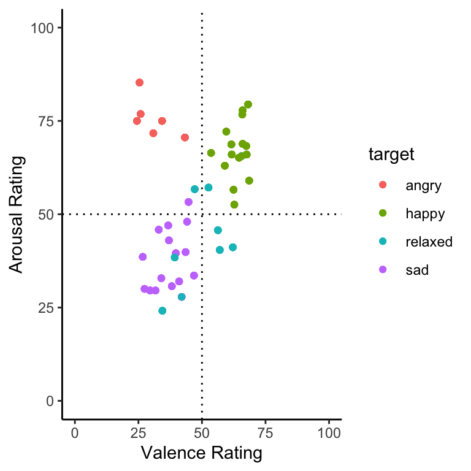

```r
lab_data %>%
  group_by(file) %>%
  mutate(valence = mean(valence),
            arousal = mean(arousal)
            ) %>%
  ggplot2::ggplot(
    aes(x = valence,
        y = arousal,
        color = target,
        fill = target)
  ) +
  ggplot2::geom_point() +
  ggplot2::xlim(0, 100) +
  ggplot2::ylim(0, 100) +
  ggplot2::geom_vline(
    xintercept = 50,
    linetype = "dotted"
    ) +
  ggplot2::geom_hline(
    yintercept = 50,
    linetype = "dotted"
    ) +
  ggplot2::xlab("Valence Rating") +
  ggplot2::ylab("Arousal Rating") +
  ggplot2::theme_classic()
```